# Customer_Segmentation

## AllLife Credit Card Customer Segmentation

### Objective: To identify different segments in the existing customer based on their spending patterns as well as past interaction with the bank.

### Data Description:

- Data is of various customers of a bank with their credit limit, the total number of credit cards the customer has, and different channels through which customer has contacted the bank for any queries, different channels include visiting the bank, online and through a call centre.

git repo: https://github.com/GreatLearningAIML1/gl-pgp-aiml-uta-intl-may20-bunty-sunbird/tree/master/project/AllBankCustomerSegmentation

### Import libraries

```python
import warnings
warnings.filterwarnings('ignore')
```

```python
#Import all the necessary modules
import pandas as pd
import numpy as np
import os
import seaborn as sns
import matplotlib.pyplot as plt
from IPython.display import display, HTML

%matplotlib inline
```

```python
### Load data

df = pd.read_excel('Credit Card Customer Data.xlsx')
```

```python
df.head()
```

|  | Sl_No | Customer Key | Avg_Credit_Limit | Total_Credit_Cards | Total_visits_bank | Total_visits_online | Total_calls_made |
| --- | --- | --- | --- | --- | --- | --- | --- |
| 0 | 1 | 87073 | 100000 | 2 | 1 | 1 | 0 |
| 1 | 2 | 38414 | 50000 | 3 | 0 | 10 | 9 |
| 2 | 3 | 17341 | 50000 | 7 | 1 | 3 | 4 |
| 3 | 4 | 40496 | 30000 | 5 | 1 | 1 | 4 |
| 4 | 5 | 47437 | 100000 | 6 | 0 | 12 | 3 |

```python
df.shape
```

```
(660, 7)
```

```python
df.columns
```

```
Index(['Sl_No', 'Customer Key', 'Avg_Credit_Limit', 'Total_Credit_Cards',
       'Total_visits_bank', 'Total_visits_online', 'Total_calls_made'],
      dtype='object')
```

### Univariate Analysis

```python
## All data is contineous

df.dtypes
```

```
Sl_No                  int64
Customer Key           int64
Avg_Credit_Limit       int64
Total_Credit_Cards     int64
Total_visits_bank      int64
Total_visits_online    int64
Total_calls_made       int64
dtype: object
```

```python
# find the number of unique values

df.nunique()

# Average Credit Limit have a good range of values, others (other than identification columns
# 'Sl_No' and 'Customer Key') have a fair range of values
```

```
Sl_No                  660
Customer Key           655
Avg_Credit_Limit       110
Total_Credit_Cards      10
Total_visits_bank        6
Total_visits_online     16
Total_calls_made        11
dtype: int64
```

```python
# 'Sl_No' and 'Customer Key' is an identification value and is not required for data analysis

df.drop(['Sl_No', 'Customer Key'], axis=1, inplace=True)
```

```python
## Descriptive statistics

df.describe().T
```

|  | count | mean | std | min | 25% | 50% | 75% | max |
| --- | --- | --- | --- | --- | --- | --- | --- | --- |
| Avg_Credit_Limit | 660.0 | 34574.242424 | 37625.487804 | 3000.0 | 10000.0 | 18000.0 | 48000.0 | 200000.0 |
| Total_Credit_Cards | 660.0 | 4.706061 | 2.167835 | 1.0 | 3.0 | 5.0 | 6.0 | 10.0 |
| Total_visits_bank | 660.0 | 2.403030 | 1.631813 | 0.0 | 1.0 | 2.0 | 4.0 | 5.0 |
| Total_visits_online | 660.0 | 2.606061 | 2.935724 | 0.0 | 1.0 | 2.0 | 4.0 | 15.0 |
| Total_calls_made | 660.0 | 3.583333 | 2.865317 | 0.0 | 1.0 | 3.0 | 5.0 | 10.0 |

- Average Credit Limit and Total visit online are right skewed
- Others are fairly normalized
- There are no negative or incorrect values

We will validate it again visually in the pairplot

```python
# Find any missing values

df.isnull().any()

# No missing values
```

```
Avg_Credit_Limit       False
Total_Credit_Cards     False
Total_visits_bank      False
Total_visits_online    False
Total_calls_made       False
dtype: bool
```

```python
# Find any duplicates

df[df.duplicated(keep="last")]
```

|  | Avg_Credit_Limit | Total_Credit_Cards | Total_visits_bank | Total_visits_online | Total_calls_made |
| --- | --- | --- | --- | --- | --- |
| 17 | 8000 | 2 | 0 | 3 | 4 |
| 29 | 8000 | 4 | 0 | 4 | 7 |
| 56 | 6000 | 1 | 0 | 2 | 5 |
| 250 | 18000 | 6 | 3 | 1 | 4 |
| 252 | 9000 | 4 | 5 | 0 | 4 |
| 257 | 10000 | 6 | 4 | 2 | 3 |
| 310 | 5000 | 4 | 5 | 0 | 1 |
| 320 | 12000 | 6 | 5 | 2 | 1 |
| 334 | 8000 | 7 | 4 | 2 | 0 |
| 425 | 47000 | 6 | 2 | 0 | 4 |
| 464 | 52000 | 4 | 2 | 1 | 2 |

```python
# Treat duplicates

df.drop_duplicates(keep='last', inplace=True)

df[df.duplicated(keep="last")]
```

|  | Avg_Credit_Limit | Total_Credit_Cards | Total_visits_bank | Total_visits_online | Total_calls_made |
| --- | --- | --- | --- | --- | --- |

```python
df.shape
```

```
(649, 5)
```

```python
def box_independent_hue(independent):
    plt.figure(figsize=(10,7))
    sns.boxplot(data=df, x = 'Target', y = independent);
    plt.show()

def box_independent(independent):
    plt.figure(figsize=(10,7))
    sns.boxplot(data=df, x = independent);
    plt.show()

def dist_plot(independent, skip_dist_plot=False):
    if skip_dist_plot:
        return
    plt.figure(figsize=(10,7))
    sns.distplot(df[independent]);

def dist_plot_hue(independent):
    plt.figure(figsize=(10,7))
    # sns.countplot(x=independent, hue='Target', data=df);
    plt.hist(df[independent], density=True)

def density_plot(independent, dependent):
    sns.distplot(df[df[dependent]=='no'][independent],color='r',label=0)
    sns.distplot(df[df[dependent]=='yes'][independent],color='g',label=1)
    plt.legend()
    plt.show()

def univariant_contineous(independent, dependent, skip_dist_plot=False):
    # density_plot(independent, dependent)
    box_independent(independent)
    # box_independent_hue(independent)
    dist_plot_hue(independent)
    dist_plot(independent, skip_dist_plot)
```

```python
df.columns
```

```
Index(['Avg_Credit_Limit', 'Total_Credit_Cards', 'Total_visits_bank',
       'Total_visits_online', 'Total_calls_made'],
      dtype='object')
```

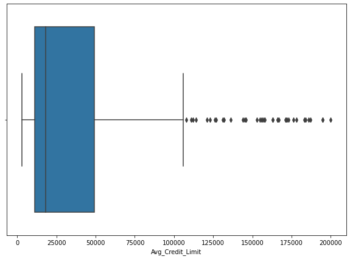

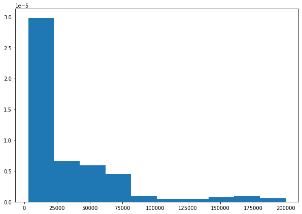

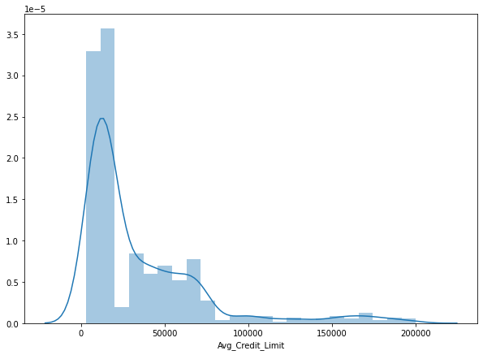

```python
univariant_contineous('Avg_Credit_Limit', 'Target')
```

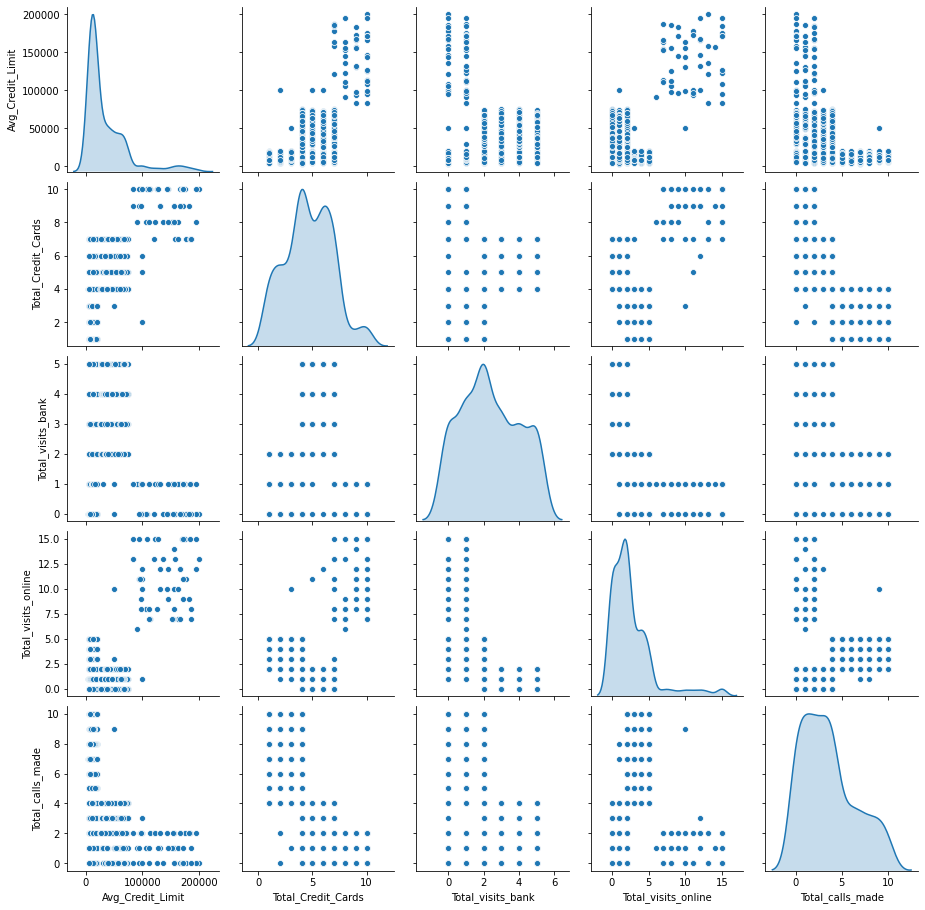

```python
sns.pairplot(data=df, diag_kind='kde')
```

```python
# Observations
# From diagonal plots we can see 'Total_Credit_Cards' has minimum 4 humps (peaks)
# 'Total_visit_banks' - shows one high peak and 2 small peaks close
# 'Avg_Cedit_Limit' and 'Total_visits_online' is highly skewed to the right and also got one prominent peak and 2 small peaks
# 'Total_calls_made' shows 2 peaks

# from bivariate plots we can see that 'Average_Credit_Limit' have a good correlation with 'Total_Credit_Cards',
# 'Total_visits_online' and 'Total_calls_made'
```

```python
df.corr()
```

|  | Avg_Credit_Limit | Total_Credit_Cards | Total_visits_bank | Total_visits_online | Total_calls_made |
| --- | --- | --- | --- | --- | --- |
| Avg_Credit_Limit | 1.000000 | 0.612623 | -0.099157 | 0.552941 | -0.418351 |
| Total_Credit_Cards | 0.612623 | 1.000000 | 0.311524 | 0.169961 | -0.653325 |
| Total_visits_bank | -0.099157 | 0.311524 | 1.000000 | -0.554078 | -0.504256 |
| Total_visits_online | 0.552941 | 0.169961 | -0.554078 | 1.000000 | 0.125480 |
| Total_calls_made | -0.418351 | -0.653325 | -0.504256 | 0.125480 | 1.000000 |

```python
# Observation

# Most of the features have a fairly good correlation but not all. We will draw the heatmap and get more clarity.
```

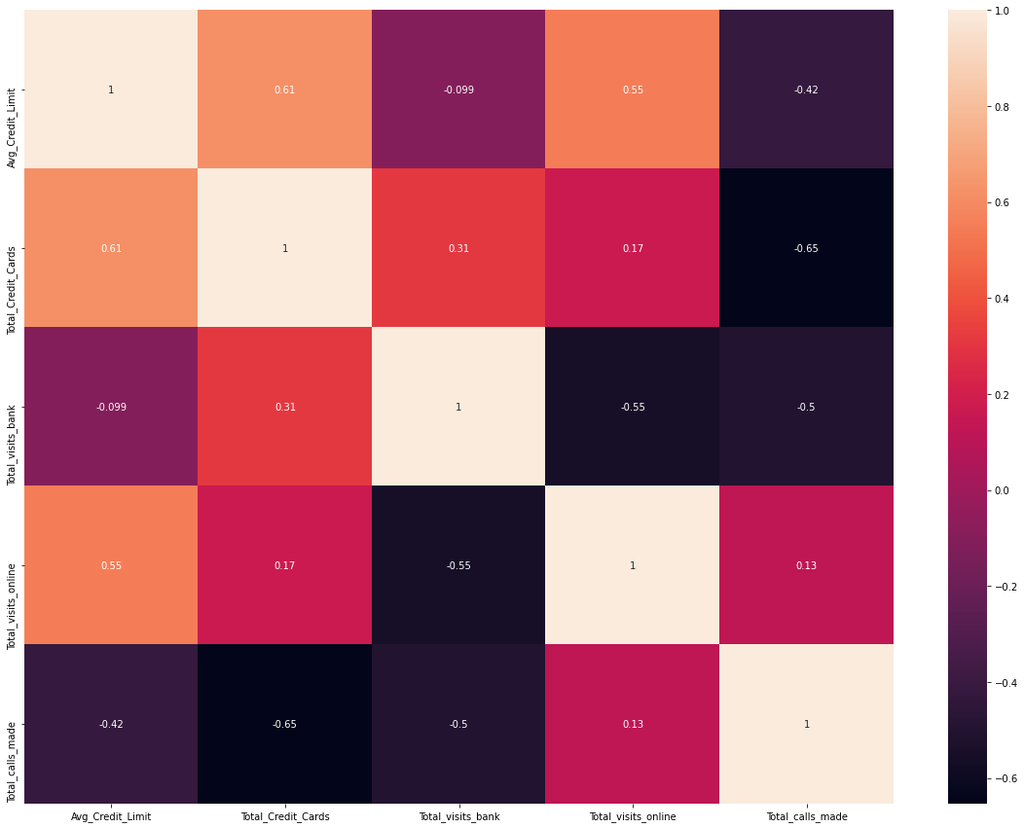

```python
plt.figure(figsize=(20,15))
sns.heatmap(df.corr(),annot=True)
```

```python
# Observation

# 'Avg_Credit_Limit' have a good (not too strong) correlation with 'Total_Credit_Cards', 'Total_visits_online'
#. and 'Total_calls_made'

# 'Total_Credit_Cards' have a good (not too strong) correlation with 'Total_calls_made'

# 'Total_visits_bank' and 'Total_visits_online' are fairly correlated
```

### Checking outliers and treating if needed

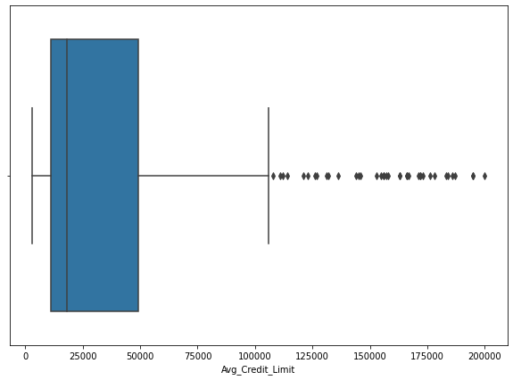

```python
box_independent('Avg_Credit_Limit')

# 'Avg_Credit_Limit' needs outlier treatment
```

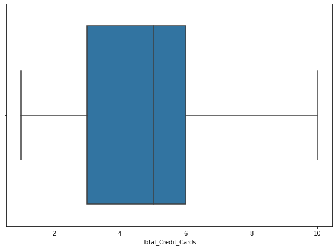

```python
box_independent('Total_Credit_Cards')

# no outliers for 'Total_Credit_Cards'
```

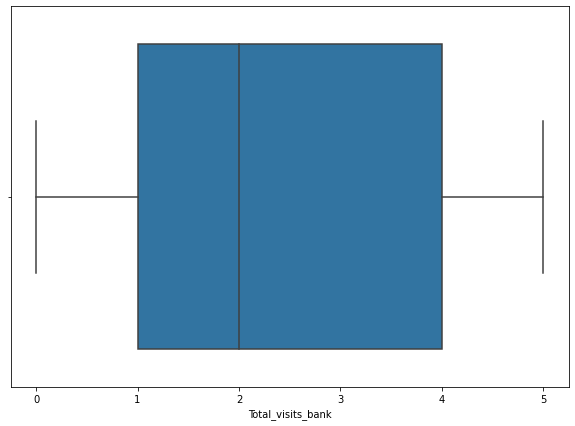

```python
box_independent('Total_visits_bank')

# no outliers for 'Total_visits_bank'
```

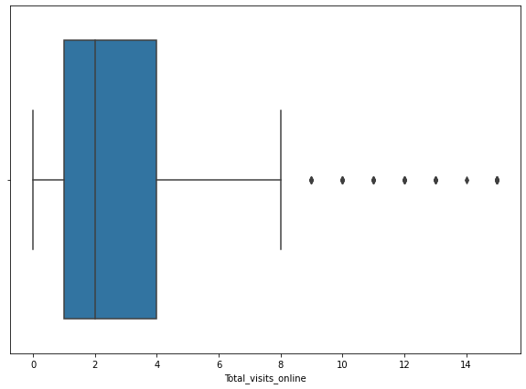

```python
box_independent('Total_visits_online')

# few outliers for 'Total_visits_online' but the max value is 15 and looks like a perfectly legitimate value for an
# online visit
```

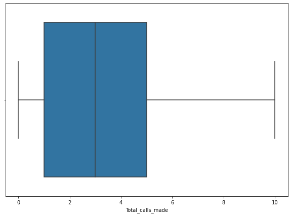

```python
box_independent('Total_calls_made')

# no outliers for 'Total_calls_made'
```

```python
# Treat outliers for 'Avg_Credit_Limit'
df['Avg_Credit_Limit'] = np.log(df['Avg_Credit_Limit'])
```

```python
# We will not treat outliers for 'Total_visits_online'. Since the max visit value is 15 and looks like a perfectly
# legitimate value
```

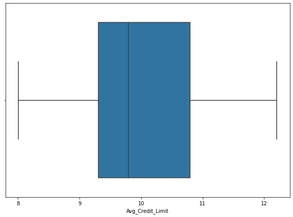

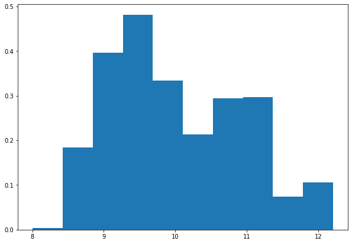

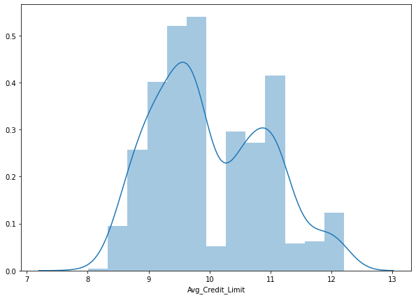

```python
# Checking the outliers below after treatment looks much better, no more outliers. Now, the average score
# have 2 prominent and 1 small guassian

univariant_contineous('Avg_Credit_Limit', 'Target')
```